# Ando and Mallory (2012)

Conservation portfolios under climate uncertainty

AREC 615

## Conservation decisions precede climate outcomes

Land protection commits resources now. Habitat quality depends on future climate.

- A region with excellent habitat today may perform poorly in a warmer climate.
- Conservation across regions can reduce exposure to a shared uncertain future.

Ando and Mallory (2012), PNAS 109(17):6484–6489, pp. 6484–6485.

## Wetland conservation in the Prairie Pothole Region

The study divides the US portion into **Western, Central, and Eastern** subregions.

The conservation outcome is the **cover-cycle index (CCI)**, an indicator of wetland habitat quality.

The planner chooses fractions of conservation land in each region.

Paper Fig. 1 and discussion, pp. 6484–6485. Geographic and institutional setting refers to the study period.

## Four joint climate scenarios

| Region | Historic | +2°C | +4°C | +4°C, wetter |
| --- | --- | --- | --- | --- |
| Western | 0.290 | 0.178 | 0.124 | 0.168 |
| Central | 0.718 | 0.587 | 0.251 | 0.503 |
| Eastern | 0.317 | 0.561 | 0.584 | 0.654 |

Each column describes **the same climate future across all three regions**.

“Wetter” means 10% more precipitation in the +4°C scenario.

Paper Table 1, p. 6485. Values are average CCI from ecological projections.

## Habitat quality shifts across regions

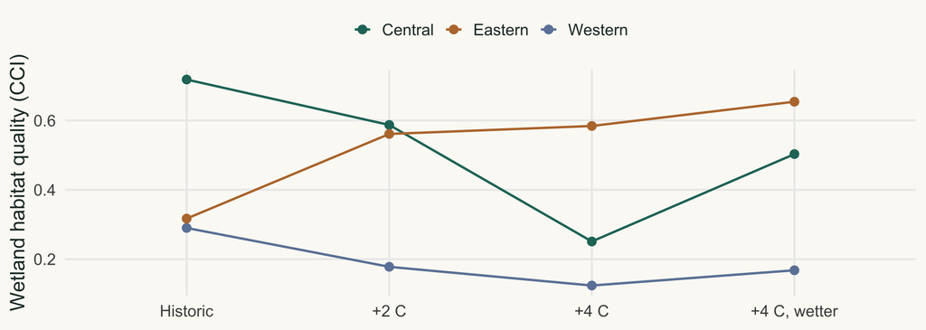

## The paper compares two probability distributions

| Assumption | Historic | +2°C | +4°C | +4°C, wetter |
| --- | --- | --- | --- | --- |
| No change likely | 0.80 | 0.10 | 0.05 | 0.05 |
| Uniform | 0.25 | 0.25 | 0.25 | 0.25 |

These are **alternative assumptions about probabilities**, rather than estimated climate forecasts.

Changing probabilities changes both expected returns and covariance.

Paper Table 1 and discussion, p. 6485.

## A portfolio is a set of land shares

Let $w_i$ denote the fraction of protected land in region $i$.

$$w_W+w_C+w_E=1,\qquad w_i\geq 0.$$

In climate scenario $s$, the benefits-only portfolio yields

$$R_s(w)=\sum_i w_i\,\mathrm{CCI}_{si}.$$

An allocation of six million acres would place $6{,}000{,}000w_i$ acres in region $i$.

## Expected benefits are linear in the shares

With scenario probabilities $p_s$, define $\mu_i=\sum_s p_s R_{si}$.

$$E[R(w)]=\sum_i w_i\mu_i=\mu^\top w.$$

| Region | No change likely | Uniform |
| --- | --- | --- |
| Western | 0.264 | 0.190 |
| Central | 0.671 | 0.515 |
| Eastern | 0.372 | 0.529 |

## Portfolio risk depends on covariance

$$\operatorname{Var}(R(w))=w^\top\Sigma w
=\sum_i w_i^2\sigma_i^2+2\sum_{i<j}w_iw_j\sigma_{ij}.$$

- The first terms reflect uncertainty within each region.
- Cross terms capture how regional outcomes move together.
- Negative covariance can reduce the variance of the combined outcome.

We minimize **variance** and display risk as **standard deviation**.

## The covariance matrix comes from joint outcomes

$$\Sigma_{ij}=\sum_s p_s(R_{si}-\mu_i)(R_{sj}-\mu_j).$$

Under uniform probabilities, the implied **correlations** are:

|  | Western | Central | Eastern |
| --- | --- | --- | --- |
| Western | 1.00 | 0.89 | -0.90 |
| Central | 0.89 | 1.00 | -0.65 |
| Eastern | -0.90 | -0.65 | 1.00 |

Calculated from Table 1. Correlation standardizes covariance by regional standard deviations.

## The constrained optimization problem

For a specified expected-return target $\bar R$:

$$\begin{aligned}
\min_w\quad &w^\top\Sigma w\\
\text{subject to}\quad &\mu^\top w=\bar R,\\
&\mathbf1^\top w=1,\\
&w\geq0.
\end{aligned}$$

Three decision variables, two equalities, and three nonnegativity bounds.

Paper Eq. 1, p. 6488. Nonnegative shares follow the text and reported zero-weight solutions.

## Full KKT conditions

For the expected-return and land-share equalities, use multipliers $\lambda$ and $\eta$. For $w_i\geq0$, use $\nu_i$.

$$\mathcal L=w^\top\Sigma w+\lambda(\bar R-\mu^\top w)
+\eta(1-\mathbf1^\top w)-\nu^\top w.$$

$$\begin{aligned}
\text{Stationarity:}\quad &2\Sigma w-\lambda\mu-\eta\mathbf1-\nu=0,\\
\text{Primal feasibility:}\quad &\mu^\top w=\bar R,\quad\mathbf1^\top w=1,\quad w_i\geq0,\\
\text{Dual feasibility:}\quad &\nu_i\geq0,\quad\lambda,\eta\in\mathbb R,\\
\text{Complementary slackness:}\quad &\nu_iw_i=0,\qquad i\in\{W,C,E\}.
\end{aligned}$$

**Equality multipliers can have either sign.** Each nonnegativity bound has its own multiplier.

## KKT conditions explain regional entry and exit

For each region $i$, stationarity gives

$$2(\Sigma w)_i-\lambda\mu_i-\eta=\nu_i.$$

**Included region:** $w_i>0$ implies $\nu_i=0$, so

$$2(\Sigma w)_i=\lambda\mu_i+\eta.$$

**Excluded region:** $w_i=0$ permits $\nu_i\geq0$, so

$$2(\Sigma w)_i\geq\lambda\mu_i+\eta.$$

An excluded region can satisfy equality when its bound multiplier is zero.

## One numerical solution

Under uniform probabilities, require expected CCI of **0.510**.

| Region | Land share |
| --- | --- |
| Western | 0.040 |
| Central | 0.385 |
| Eastern | 0.575 |

The minimum standard deviation is **0.058**.

The all-Eastern allocation has expected CCI **0.529** and standard deviation **0.127**.

## Setting up SQP in R

```r
mu <- moments_example$mu
Sigma <- moments_example$Sigma
target <- 0.51
objective <- function(w) drop(t(w) %*% Sigma %*% w)
gradient <- function(w) drop(2 * Sigma %*% w)
equalities <- function(w) c(sum(w) - 1, sum(mu * w) - target)
jacobian <- function(w) rbind(rep(1, 3), mu)
```

Equalities are written as **residuals equal to zero**. Each Jacobian **row** contains the derivatives of one constraint.

## Solving one portfolio in R

```r
fit <- nloptr::nloptr(
  x0 = rep(1/3, 3), lb = rep(0, 3),
  eval_f = objective, eval_grad_f = gradient,
  eval_g_eq = equalities, eval_jac_g_eq = jacobian,
  opts = list(algorithm = "NLOPT_LD_SLSQP",
              xtol_rel = 1e-12, maxeval = 2000)
)
setNames(fit$solution, names(mu))
```

```
   Western    Central    Eastern
0.03986907 0.38486910 0.57526182
```

`x0` starts at equal thirds; `lb` enforces nonnegative shares. Check convergence and both equality residuals.

## The efficient frontier contains the best tradeoffs

1. Find the global minimum-variance allocation without a return target.
2. Increase the target from that allocation’s mean to the largest feasible mean.
3. Solve again at each target and plot expected return against standard deviation.

Targets below the minimum-variance mean generate a **dominated lower branch**.

## Benefits-only conservation portfolios

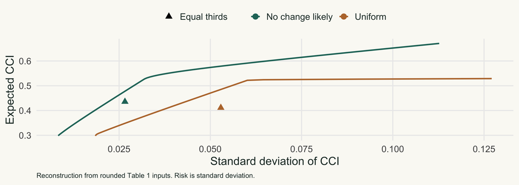

## Regional shares change along the frontier

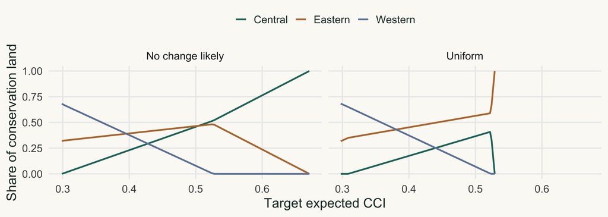

## Conservation costs vary across regions

| Region | Historic | +2°C | +4°C | +4°C, wetter |
| --- | --- | --- | --- | --- |
| Western | 0.601 | 0.631 | 0.631 | 0.536 |
| Central | 0.697 | 0.720 | 0.720 | 0.659 |
| Eastern | 1.210 | 1.230 | 1.230 | 1.200 |

Costs are in **thousands of dollars per acre**.

The paper uses future land values to represent the opportunity cost of conservation.

Table 1, p. 6485, and Methods, p. 6488. Historical study values, not current prices.

## Benefit–cost returns use scenario-specific ratios

Define each regional return as

$$R_{si}=\frac{\mathrm{CCI}_{si}}{\mathrm{Cost}_{si}}.$$

Then calculate $\mu$ and $\Sigma$ from this new scenario matrix and solve the same portfolio problem.

$$E[\mathrm{CCI}/\mathrm{Cost}]\neq
\frac{E[\mathrm{CCI}]}{E[\mathrm{Cost}]}\quad\text{in general}.$$

Under uniform probabilities, **Central** now has the highest expected return.

## Portfolios with benefit–cost returns

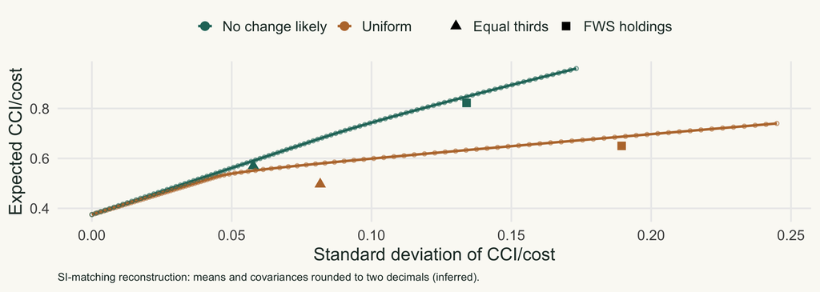

## The model connects risk to the allocation decision

- A region’s value depends on its contribution to the **whole portfolio**.
- Scenario probabilities affect both means and covariances.
- Land costs can change the preferred allocation.
- Risk preferences select among efficient portfolios.

## Backup: land shares and benefit–cost ratios

The paper’s scenario return is an average of regional ratios:

$$\sum_i w_i\frac{B_{si}}{C_{si}}.$$

The ratio of total benefits to total costs for those land shares is:

$$\frac{\sum_i w_iB_{si}}{\sum_i w_iC_{si}}.$$

These expressions generally differ. With spending shares $v_i$ and known costs, $\sum_i v_iB_i/C_i$ measures benefits per dollar of the budget.

**The code preserves the paper’s land-share formulation.**

## Backup: published results and reconstruction

| Quantity | Paper reports | Table 1 reconstruction |
| --- | --- | --- |
| Equal-thirds CCI SD, no change likely | 0.110 | 0.027 |
| Equal-thirds CCI SD, uniform | 0.130 | 0.053 |
| $1bn total CCI, all Eastern | 357,442 | 434,497 |
| $1bn total CCI, all Central | 1,057,183 | 736,409 |

Budget calculations here use probability-weighted land costs. The script also reports alternative cost conventions.

**Numerical verification of the stated model does not establish exact replication of the published results.**

Paper Tables 1–2 and Methods, p. 6488. Full comparisons: paper_audit and budget_audit in AM_model.R.

## Reference

Ando, Amy W., and Mindy L. Mallory. 2012. “Optimal portfolio design to reduce climate-related conservation uncertainty in the Prairie Pothole Region.” *Proceedings of the National Academy of Sciences* 109(17):6484–6489.

[doi:10.1073/pnas.1114653109](https://doi.org/10.1073/pnas.1114653109)

Interactive walkthrough: `AM_teaching.R`  
Model and publication audit: `AM_model.R`  
SI reconstruction: `reproduce_SI.R`  
Numerical checks: `validate_model.R`